# Aula 9 - Introdução à Econometria

João Ricardo F. de Lima

17 de maio de 2022.

# 1 Quebra de Pressupostos do Modelo Clássico de Regressão Linear

## 1.1 Heterocedasticidade

Ocorre quando a variância do termo de erro não é constante $(\sigma^2_i)$. As fontes principais são: presença de *outliers*, modelo incorretamente especificado, assimetria na distribuição de um ou mais regressores e erros de digitação dos dados.

É mais comum em dados de seção cruzada.

Com as relação às propriedades dos estimadores de MQO, na presença de **heterocedasticidade** continuam não-viesados e consistentes, mas não são mais eficientes. O estimador eficiente, ou seja, com variância mínima é o de Mínimos Quadrados Generalizados (MQG).

## 1.2 Consequências da Heterocedasticidade

O uso do método de MQO na presença de **heterocedasticidade** leva a resultados incorretos das significâncias (Testes t e F), levando a conclusões e inferências que podem estar equivocadas.

## 1.3 Como detectar a Heterocedasticidade?

Sempre uma boa análise gráfica dos resíduos é importante. Contudo, existem testes formais para análise de heterocedasticidade. Os principais são os de White e Breusch-Pagan-Godfrey (BPG).

## 1.4 Exemplo no R - Estimação do Modelo e Verificação de Normalidade e Multicolinearidade

```r
#Direcionado o R para o Diretorio a ser trabalhado
setwd('C:/Users/Joao Ricardo Lima/Dropbox/tempecon/facape/')

#Limpa o Ambiente Global
rm(list=ls())

#Inicio do Script
#Pacotes a serem utilizados
library(car)
library(lmtest)
library(sandwich)
library(corrplot)
library(FinTS)
library(tseries)

#Lendo os dados no R de um arquivo CSV
dados <- read.csv2('wage.csv', header = T,
                   sep=';', dec='.')

dados <- dados[,-1] #Retira a primeira coluna

#Regressao Multipla
regressao1 <- lm(log(wage) ~ female + union
                 + educ + exper, data=dados)
summary(regressao1)
```

```
##
## Call:
## lm(formula = log(wage) ~ female + union + educ + exper, data = dados)
##
## Residuals:
##      Min       1Q   Median       3Q      Max
## -2.50184 -0.28293  0.00404  0.30620  1.81857
##
## Coefficients:
##              Estimate Std. Error t value Pr(>|t|)
## (Intercept)  0.861721   0.073504  11.723  < 2e-16 ***
## female      -0.253681   0.026718  -9.495  < 2e-16 ***
## union        0.167581   0.036957   4.534 6.31e-06 ***
## educ         0.101556   0.004812  21.106  < 2e-16 ***
## exper        0.013051   0.001174  11.113  < 2e-16 ***
## ---
## Signif. codes:  0 '***' 0.001 '**' 0.01 '*' 0.05 '.' 0.1 ' ' 1
##
## Residual standard error: 0.4774 on 1284 degrees of freedom
## Multiple R-squared:  0.3391, Adjusted R-squared:  0.337
## F-statistic: 164.7 on 4 and 1284 DF,  p-value: < 2.2e-16
```

```r
#Teste de Normalidade dos residuos
jarque.bera.test(regressao1$residuals)
```

```
##
##  Jarque Bera Test
##
## data:  regressao1$residuals
## X-squared = 249.28, df = 2, p-value < 2.2e-16
```

```r
shapiro.test(regressao1$residuals)
```

```
##
##  Shapiro-Wilk normality test
##
## data:  regressao1$residuals
## W = 0.9808, p-value = 4.596e-12
```

```r
#Analise de Multicolinearidade
#Matriz de Correlacoes das variaveis explicativas
x <- dados[, c(2,3,4,6)]
cor(x)
```

```
##                educ       exper      female        union
## educ    1.000000000 -0.18010301 -0.03143916  0.003966952
## exper  -0.180103012  1.00000000 -0.02265681  0.154319024
## female -0.031439159 -0.02265681  1.00000000 -0.088856935
## union   0.003966952  0.15431902 -0.08885694  1.000000000
```

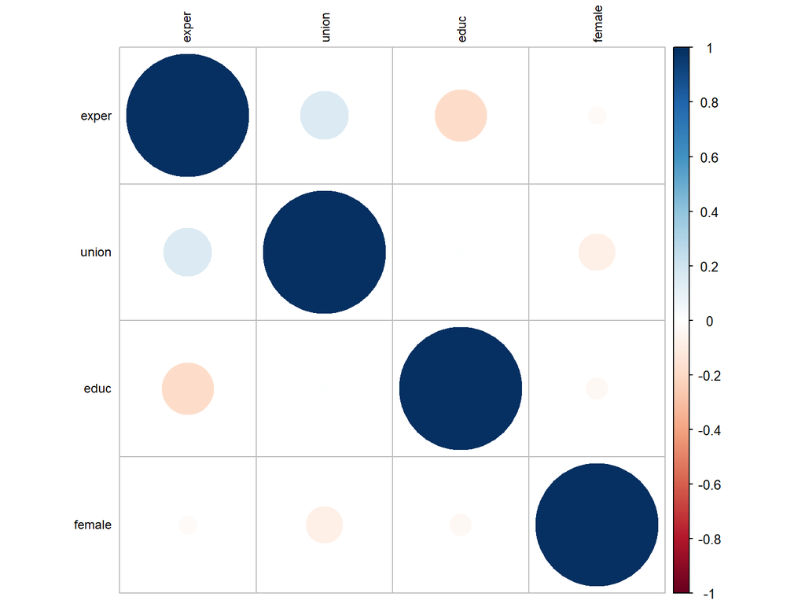

```r
corrplot(cor(x), order="hclust", tl.col="black", tl.cex = .75)
```

```r
#Calculo do Fator de Inflacao da Variancia
vif(lm(log(wage) ~ female + union + educ + exper, data=dados))
```

```
##   female    union     educ    exper
## 1.009170 1.033014 1.035788 1.060093
```

## 1.5 Verificação dos resíduos

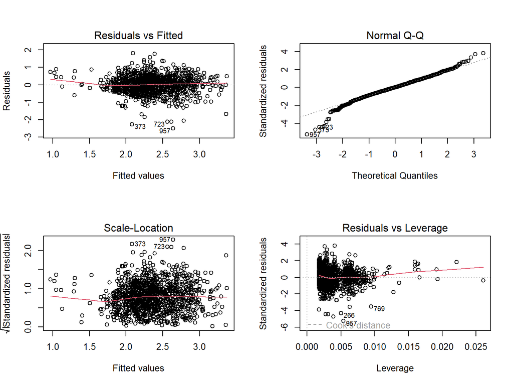

```r
#Analise dos residuos do modelo
par(mfrow=c(2,2))
plot(regressao1)
```

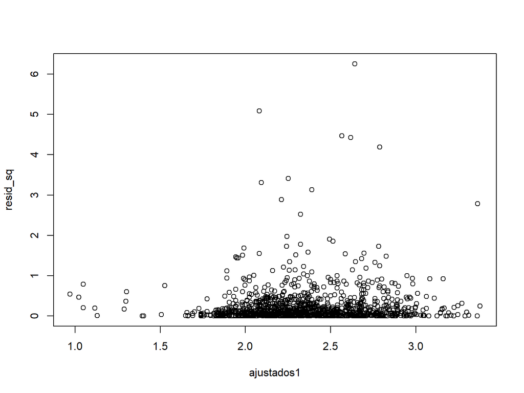

```r
#Salvando os residuos do modelo e os valores estimados
resid_sq <- (regressao1$residuals)^2
ajustados1 <- regressao1$fitted.values
par(mfrow=c(1,1))
plot(ajustados1, resid_sq)
```

## 1.6 Heterocedasticidade: teste de White

A **hipótese nula** do Teste de White é os **resíduos são homocedásticos**. Após a regressão, pegar os resíduos ao quadrado e estimar contra os regressores e estes ao quadrado. é possível incluir produtos cruzados também. A estatística de teste $nR^2$ segue uma distribuição de qui-quadrado com graus de liberdade igual ao numero de parâmetros estimados. É um teste para grandes amostras.

```r
#Testes de Heterocedasticidade de White
#Caso especial do BPG
#H0: Residuos sao homocedasticos.
regres_white <- lm(log(wage) ~ female +  union
                 + educ + exper + I(educ^2) + I(exper^2), data=dados)
bptest(regres_white)
```

```
##
##  studentized Breusch-Pagan test
##
## data:  regres_white
## BP = 35.869, df = 6, p-value = 2.922e-06
```

## 1.7 Heterocedasticidade: teste de BPG

Semelhante ao Teste de White, mas os resíduos ao quadrado são estimados no teste BPG contra os regressores originais apenas. Na estatística de teste é possível usar o valor do F ou então o $R^2$ multiplicado pelo tamanho da amostra “n”. A estatística de teste segue a distribuição de qui-quadrado com graus de liberdade igual ao número de regressores no modelo. **A hipótese nula é homocedasticidade**.

```r
#Testes de Heterocedasticidade de White
#Caso especial do BPG
#H0: Residuos sao homocedasticos.
#Testes de Heterocedasticidade de Breusch-Pagan
bptest(regressao1)
```

```
##
##  studentized Breusch-Pagan test
##
## data:  regressao1
## BP = 30.207, df = 4, p-value = 4.441e-06
```

```r
#Testes de Heterocedasticidade NCV
ncvTest(regressao1)
```

```
## Non-constant Variance Score Test
## Variance formula: ~ fitted.values
## Chisquare = 9.964166, Df = 1, p = 0.0015962
```

## 1.8 Uso do pacote {performance}

```r
pacman::p_load(
"performance",
"lme4",
"see",
"qqplotr"
)

model_performance(regressao1)
```

```
## # Indices of model performance
##
## AIC      |       BIC |    R2 | R2 (adj.) |  RMSE | Sigma
## --------------------------------------------------------
## 7797.771 | 13867.488 | 0.339 |     0.337 | 0.477 | 0.477
```

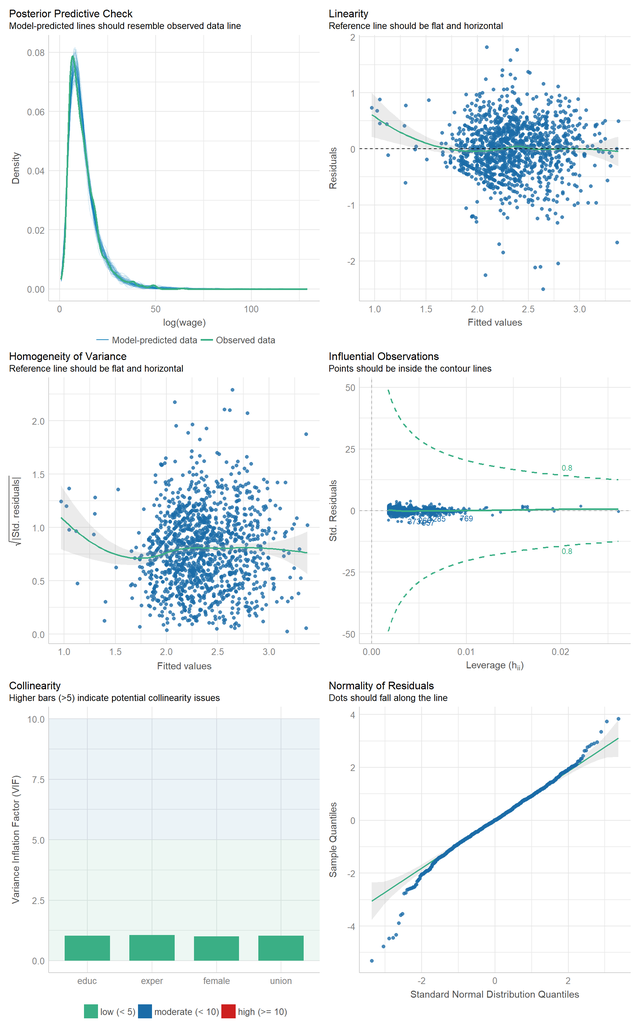

```r
check_model(regressao1)
```

## 1.9 Heterocedasticidade: como corrigir?

Usar mínimos quadrados ponderados se conhecer a verdadeira variância heterocedástica $\sigma^2_i$. Contudo, raramente isto ocorre. O que mais se usa é transformação logarítmica de variáveis com grande variância e o procedimento de White para estimar erros-padrão robustos. O procedimento não altera a estimação no ponto, apenas os erros-padrão corrigindo a heterocedasticidade.

A correção clássica de White para a matriz de variância dos coeficientes é dada por:

$$Var(\hat \beta|X)=(X'X)^{-1}X'diag(e^2)X(X'X)^{-1}$$
em que $e^2$ são os resíduos ao quadrado e $X$ é a matriz de variáveis explicativas do modelo.

Contudo, existem diversos outros métodos de ajustamento desta fórmula para a matriz de var-cov dos resíduos, denotada por $\Omega$. No R, a opção “const” retorna os resultados de $\sigma^2(X'X)^{-1}$. As outras opções retornam estimadores de White na forma da expressão e diferem em termos de $(X'X)^{-1}X' \Omega X(X'X)^{-1}$ e diferem em como é $\Omega$. A diagonal de $\Omega$ será formada pelos elementos $\omega_i$ exposto para cada opção de HC (hc0, hc1, hc2, hc3, hc4):

1. const = $\omega_i= \hat \sigma^2$
2. HC0 = $\omega_i= \hat u_i^2$ é matriz clássica de correção de Eicker (1963) e popularizada por White (1980);
3. HC1 = $\omega_i= \frac {n}{n-k}\hat u_i^2$
4. HC2 = $\omega_i= \frac {\hat u_i^2}{1-h_i}$
5. HC3 = $\omega_i= \frac {\hat u_i^2}{(1-h_i)^2}$
6. HC4 = $\omega_i= \frac {\hat u_i^2}{(1-h_i)^{\delta_i}}$ é a matriz de correção conforme Cribari-Neto (2004) para aperfeiçoar a performance em pequenas amostras com presença de observações influentes.

“hc1”, “hc2” e “hc3” as matrizes de correção sugeridas por MacKinnon e White (1985) e aperfeiçoadas para pequenas amostras conforme Long e Ervin (2000).

para $h_i=H_{ii}$ como os elementos diagonais da matriz estimada, $\bar h$ é sua média é $\delta_i=min {\{4, h_i/ \bar h}\}$. A opção que retorna os mesmos resultados que o “padrão” de correção de White no Stata e Eviews é a “hc1”.

```r
#Correcao da Heterocedasticidade
regressao1 <- lm(log(wage) ~ female + union
                 + educ + exper, data=dados)
coeftest(regressao1, vcov=vcovHC, type='HC1') #(Eviews)
```

```
##
## t test of coefficients:
##
##               Estimate Std. Error t value  Pr(>|t|)
## (Intercept)  0.8617208  0.0718852 11.9875 < 2.2e-16 ***
## female      -0.2536808  0.0266746 -9.5102 < 2.2e-16 ***
## union        0.1675814  0.0305151  5.4918 4.792e-08 ***
## educ         0.1015562  0.0051254 19.8143 < 2.2e-16 ***
## exper        0.0130513  0.0012413 10.5143 < 2.2e-16 ***
## ---
## Signif. codes:  0 '***' 0.001 '**' 0.01 '*' 0.05 '.' 0.1 ' ' 1
```

```r
coeftest(regressao1, vcov=vcovHC, type='HC4') #sugerido (2011)
```

```
##
## t test of coefficients:
##
##               Estimate Std. Error t value  Pr(>|t|)
## (Intercept)  0.8617208  0.0724911 11.8873 < 2.2e-16 ***
## female      -0.2536808  0.0266915 -9.5042 < 2.2e-16 ***
## union        0.1675814  0.0306210  5.4728 5.323e-08 ***
## educ         0.1015562  0.0051722 19.6348 < 2.2e-16 ***
## exper        0.0130513  0.0012439 10.4923 < 2.2e-16 ***
## ---
## Signif. codes:  0 '***' 0.001 '**' 0.01 '*' 0.05 '.' 0.1 ' ' 1
```